# R Packages

Software for Robust Analytics

February 15, 2024

`Software/Software.Rmd`

$\otimes$ | hub | map | models | model building| $\rightarrow$ | exDE | pf.memory | mobwork | MicroMoB | motrap.micro

## $\odot$

Five software packages have been developed to support RAMP:

- `exDE` is a set of algorithms to build and solve systems of differential equations describing the epidemiology, transmission dynamics, and control of malaria and other mosquito-transmitted pathogens. It is an open-access R package on [github](https://github.com/dd-harp/exDE/), including [documentation and vignettes](https://dd-harp.github.io/exDE/).
- `MicroMoB` is a set of algorithms to build and solve discrete time systems describing the epidemiology, transmission dynamics, and control of malaria and other mosquito-transmitted pathogens. It is an open-access R package on [`github`](https://github.com/dd-harp/MicroMoB), including [documentation and vignettes](https://dd-harp.github.io/MicroMoB/).
- `mobwork` is a set of algorithms to build an analytics pipeline using `exDE` and `MicroMoB.` It is an open-access R package on [`github`](https://github.com/dd-harp/mobwork), including [documentation and vignettes](https://dd-harp.github.io/mobwork/).
- `pf.memory` is a set of algorithms that implement a probabilistic approach to malaria epidemiology, defined in the narrow sense to include exposure, infection, disease, immunity, treatment and chemoprotection, and detection. It is an open-access R package on [github](https://github.com/dd-harp/pf.memory/), including [documentation and vignettes](https://dd-harp.github.io/pf.memory/).
- `motrap.micro` is a set of algorithms to set up and analyze micro-simulation models. It is an open-access R package on [github](https://github.com/dd-harp/motrap.micro/), including [documentation and vignettes](https://dd-harp.github.io/motrap.micro/).

## Diagram

A diagram of the relationships among software packages.

[figure not shown]

## RAMP

**RAMP** = Robust analytics for malaria policy

**A-U-R-O-G**

- **Analytics** - decision support that is based on a systematic analysis of the evidence
- **Uncertainty** - the analysis should characterize, quantify, and propagate uncertainty
- **Robust** - the advice would not change if the analysis had been done in a slightly different, but reasonable way
- **Options** - the endpoint is to recommend a specific course of action, but to discuss other policies that were nearly as good
- **Gaps** - what new information could resolve the uncertainty

*Aurog, the destroyer?*

## The Challenge

### Complexity

**Malaria is a locally peculiar, exogenously-forced, managed, complex adaptive system**

*…malaria is so moulded and altered by local conditions that it becomes a thousand different diseases and epidemiological puzzles. Like chess, it is played with a few pieces, but is capable of an infinite variety of situations.* – Hackett, 1937

### Why Model Malaria?

**Why model malaria?**

- The complexity of malaria exceeds our innate mental capabilities. We can extend these capabilities by building and analyzing mathematical models.
- Models can play a role in synthesizing information about:
  - mosquito ecology & behavior
  - human demography & behavior
  - health systems
  - vector control
  - weather
  - the evolution of resistance

### Pipelines

**Managing malaria involves working across three epochs of time**

Stable software ecosystems facilitate development of procedures and protocols to understand our current situation, and that rigorously and routinely translate evidence from the past into advice about the future.

- **Past** - all of the data we have comes from the past
- **Present** - with well-developed data systems to keep us updated on the current state of the system in stable formats
- **Future** - all of our decisions affect the future

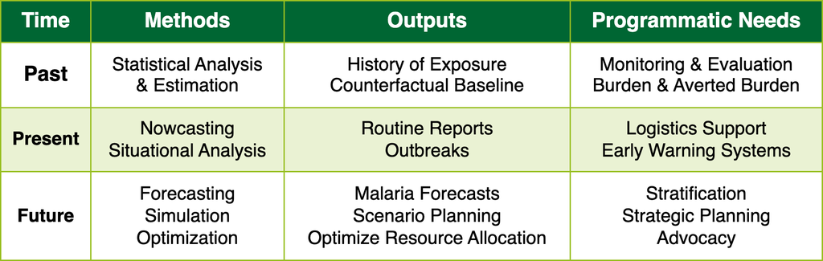

### Collaboration

**To manage complex systems, experts must collaborate in a multi-disciplinary setting.**

- Using existing systems, it is difficult to build models that were complex in more than one way. It is difficult to build model ensembles.
- Individual-based models are an exception to this rule, but the output of IBMs is itself highly complex. To run and analyze IBMs requires an additional, specialized set of skills.
- In a collaborative setting it should be possible to combine and reuse models that have already been developed
- To manage malaria, there should be an interface with algorithms that fit models to malaria data
- The analysis should serve the needs of malaria programs (*i.e.* rather than to publish papers)

## Why Software?

- **Replicability** - To make our analysis easy for others to replicate
- **Scalable Complexity** - To build model ensembles at any level of abstraction or realism that could fully propagate uncertainty
- **Transparency** - To make our analysis easy to understand and critique
- **Innovation** - To identify and fill gaps

## Missing Skills

**Existing models may not be up to the tasks we ask of them**

### Malaria Epidemiology

Malaria epidemiology, defined narrowly, is complex enough to *strangle a goat*

- Exposure
- Infection and super-infection
- Complex time-course of infection with fluctuating parasite densities
- Diagnostics and parasite detection
- Immunity
- Infectiousness
- Treatment & Chemoprotection
- Disease
  - including mild, moderate, and severe disease
  - cerebral malaria
  - malaria anemia
  - malaria in pregnancy
  - low birth weights…

[figure not shown]

### Microsimulation

Mosquito ecology and malaria spatial dynamics on point sets

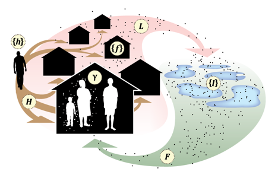

### Scalable Complexity

We need models with **SCALABLE COMPLEXITY**

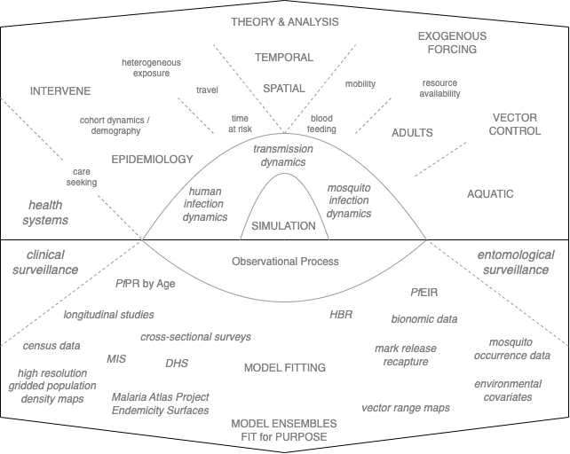

## Design Principles

**RAMP** software is designed for nimble model building, to build and analyze model ensembles, and to scale complexity from simple & abstract, up to highly realistic.

- **Modularity**
- **Flexibility**
- **Extensibility**